# DSPN2023 重力波演習

Download Jupyter Notebook

このノートブックでは、GW150914という初めて検出された重力波のデータを解析して物理量を推定します。

必要なライブラリをインポートします。

```python
import matplotlib.pyplot as plt
import numpy as np
from astropy.units import Quantity
from gwpy.signal import filter_design
from gwpy.timeseries import TimeSeries
from scipy import signal
from scipy.optimize import curve_fit
```

## データの前処理

データをダウンロードします。gwpyでは検出器とデータの時刻 (GPS時)を指定してデータをダウンロードできます。GPS時は1980年1月6日0時0分0秒 UTCを基準とした時刻です。

```python
hdata = TimeSeries.fetch_open_data('H1', 1126259450, 1126259470)
ldata = TimeSeries.fetch_open_data('L1', 1126259450, 1126259470)
```

Hanford (H1) でのデータをプロットしてみます。GPS時は値が大きくて見づらいため、ここでは、2015年9月14日 09:50:33 UTCを基準にした時間で表示することとします。

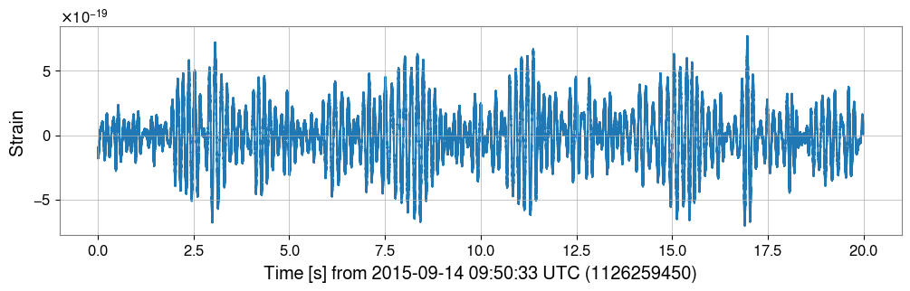

```python
# Change the starting point of time
hdata.shift('-1126259450s')
ldata.shift('-1126259450s')
# Plot of the time-series
fig, ax = plt.subplots(figsize=(12, 3))
ax.plot(hdata.times, hdata)
ax.set_xlabel('Time [s] from 2015-09-14 09:50:33 UTC (1126259450)')
ax.set_ylabel('Strain')
plt.show()
```

生データは検出器のノイズが大きく、重力波は見えません。

先ほど実行した

```
hdata = TimeSeries.fetch_open_data('H1', 1126259450, 1126259470)
```

では、`gwpy.timeseries.TimeSeries`というクラスのインスタンスが生成されました. このクラスが持つメソッドである`hdata.psd()`でその時系列データをFourier変換して、**雑音スペクトル** (PSD)を計算できます。それをプロットすることで時系列データの周波数ごとのパワー（大きさ）の分布を知ることができます。

`psd`メソッドでは、Welchの方法が使われます。Welchの方法では、データをいくつかの区間に分割して、それぞれの区間で雑音スペクトルの近似値を計算し、それらの平均値をとることでデータ全体の雑音スペクトルを求めます。引数には分割する区間の秒数を指定します。

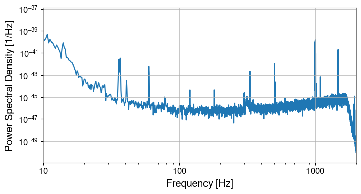

```python
hdata_psd = hdata.psd(4)
fig, ax = plt.subplots(figsize=(8, 4))
ax.loglog(hdata_psd)
ax.set_xlim(10, 2000)
ax.set_xlabel('Frequency [Hz]')
ax.set_ylabel('Power Spectral Density [1/Hz]')
plt.show()
```

PSDのプロットから、低周波($\lesssim 30$ Hz)でノイズが大きいことが分かります。また、いろいろな周波数帯でピークのようなもの(ラインノイズ)が見えていることがわかります。これは検出器で鏡を吊るす振り子などから生じるノイズです。

```python
def notch_filter(frequency, sample_rate, df=1.0, df2=0.1, output='zpk', **kwargs):
    frequency = Quantity(frequency, 'Hz').value
    sample_rate = Quantity(sample_rate, 'Hz').value
    nyq = 0.5 * sample_rate
    low1 = (frequency - df)/nyq
    high1 = (frequency + df)/nyq
    low2 = (frequency - df2)/nyq
    high2 = (frequency + df2)/nyq

    kwargs.setdefault('gpass', 1)
    kwargs.setdefault('gstop', 6)
    kwargs.setdefault('ftype', 'ellip')
    return signal.iirdesign([low1, high1], [low2, high2], output=output, **kwargs)

def apply_filter(data):
    # Bandpass
    bp = filter_design.bandpass(35, 350, data.sample_rate)
    # Notch
    lines = (14.0, 34.70, 35.30, 35.90, 36.70, 37.30, 40.95, 60.00, 120.00, 179.99, 304.99, 331.49, 510.02, 1009.99)
    notches = [notch_filter(line, hdata.sample_rate) for line in lines]
    notches.append(notch_filter(331.5, hdata.sample_rate, 10, 1))
    notches.append(notch_filter(510, hdata.sample_rate, 200, 20))
    zpk = filter_design.concatenate_zpks(bp, *notches)

    filt = data.filter(zpk, filtfilt=True)
    return filt
```

フィルタを適用します。

```python
hfilt = apply_filter(hdata)
lfilt = apply_filter(ldata)
```

両端のデータは乱れることがあるため、データの両端を除去します。

```python
# Remove edges
hdata = hdata.crop(*hdata.span.contract(1))
hfilt = hfilt.crop(*hfilt.span.contract(1))
lfilt = lfilt.crop(*lfilt.span.contract(1))
```

フィルタを適用したデータのPSDを計算し、先ほどの生データのPSDと比較するとフィルタの影響が分かります。

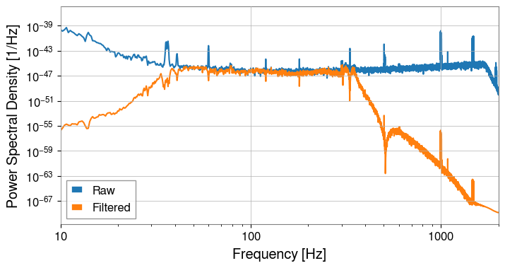

```python
hfilt_psd = hfilt.psd(4)

fig, ax = plt.subplots(figsize=(8, 4))
ax.loglog(hdata_psd, label='Raw')
ax.loglog(hfilt_psd, label='Filtered')
ax.set_xlim(10, 2000)
ax.set_xlabel('Frequency [Hz]')
ax.set_ylabel('Power Spectral Density [1/Hz]')
ax.legend()
plt.show()
```

時系列データとしても比較してみます。

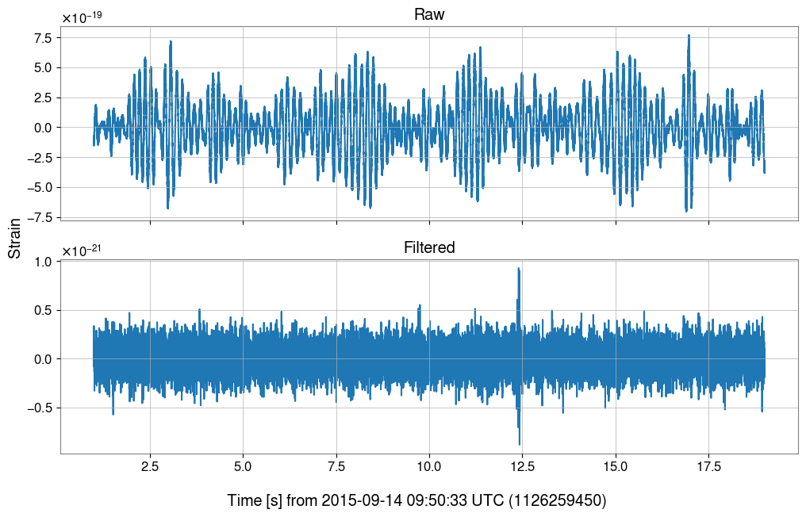

```python
fig, axes = plt.subplots(2, 1, figsize=(12, 7))
axes[0].plot(hdata.times, hdata)
axes[1].plot(hfilt.times, hfilt)
fig.supxlabel('Time [s] from 2015-09-14 09:50:33 UTC (1126259450)')
fig.supylabel('Strain', x=0.07)
axes[0].tick_params(labelbottom=False)
axes[0].set_title('Raw')
axes[1].set_title('Filtered')
plt.show()
```

すでに、検出パイプラインによってブラックホール連星の合体時刻が分かっているとします。また、検出器間での到来時刻、位相のずれをそろえるために、Hanfordでのデータを6.9 msずらして符号を反転させます。これらの値は[[Abbott et al.(2016)](https://doi.org/10.1103/PhysRevLett.116.061102)]を参照しました。

```python
merger_time = 1126259462.422 - 1126259450
hfilt.shift('-0.0069s')
hfilt *= -1
```

合体前後にフォーカスしてみます。

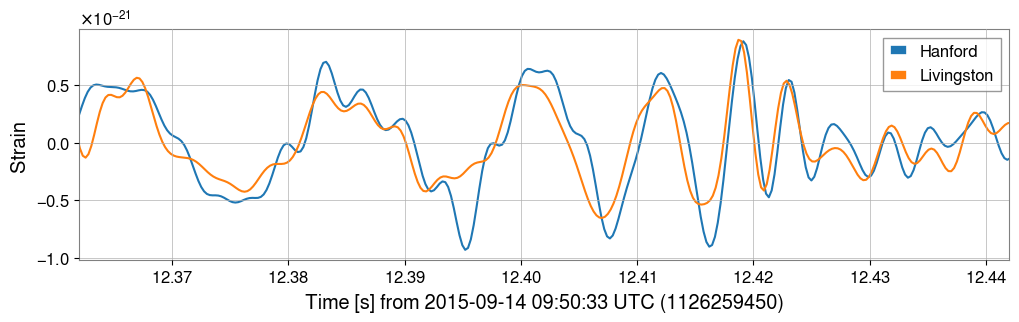

```python
fig, ax = plt.subplots(figsize=(12, 3))
ax.plot(hfilt.times.value, hfilt.value, label='Hanford')
ax.plot(lfilt.times.value, lfilt.value, label='Livingston')
ax.set_xlim(merger_time-0.06, merger_time+0.02)
ax.set_xlabel('Time [s] from 2015-09-14 09:50:33 UTC (1126259450)')
ax.set_ylabel('Strain')
ax.legend()
plt.show()
```

重力波らしき信号が見えています。このデータを使って物理量を推定します。

## 物理量の推定

ブラックホール連星のチャープ質量と有効距離を推定します。

### チャープ質量$\mathcal{M}$の推定

まず、連星ブラックホールの合体を表現する物理モデルを作ります。 ここでは2つのブラックホールが質点であるとし、それらの質量を$m_1$と$m_2$とします。2つのブラックホールは$xy$平面上の円軌道上を回転しているとし、中心からの距離をそれぞれ$r_1, r_2$、角周波数を$\omega$とします。

[figure not shown]

この系の質量四重極モーメントは

$$ Q_{ij} = \int \rho(\vec{x}) \left( x_i x_j - \frac{1}{3}r^2 \delta_{ij} \right)d^3 x = \frac{1}{2} (m_1 r_1^2 + m_2 r_2^2) I_{ij} $$

と表せます。ここで、$ I_{xx}= \cos(2 \omega t) + 1/3$, $I_{yy} = 1/3 - \cos(2 \omega t)$, $I_{xy} = I_{yx} = \sin(2 \omega t), I_{zz} = -2/3$です。換算質量:

$$ \mu = \frac{m_1 m_2}{m_1 + m_2} $$

と連星間距離 $r=r_1+r_2$ を使うと

$$ Q_{ij}(t) = \frac{1}{2} \mu r^2 I_{ij} $$

と表せます。**一般相対性理論**から、距離$d_L$からの重力波の振幅$h$は

$$ h_{ij} = \frac{2G}{c^4 d_L} \frac{d^2 Q_{ij}}{dt^2} $$

と質量四重極モーメントの2階時間微分で表せることがわかっています。この重力波の放出によるエネルギーの減少率は

$$ \frac{dE_{GW}}{dt} = \frac{c^3}{16 \pi G} \iint \vert \dot{h} \vert^2 dS = \frac{1}{5} \frac{G}{c^5} \sum_{i,j =1}^3 \frac{d^3 Q_{ij}}{dt^3} \frac{d^3 Q_{ij}}{dt^3} = \frac{32}{5}\frac{G}{c^5} \mu^2 r^4 \omega^6 $$

と計算されます。重力波の放出によって連星系が持つエネルギーは減少していき、2つのブラックホールは近づいていきます。ニュートン近似において、連星系が持つエネルギーは

$$ E_{orb} = -\frac{G M \mu}{2r} $$

と表され、その時間変化は

$$ \frac{d}{dt} E_{orb} = \frac{GM \mu}{2r^2} \dot{r} $$

です。ここで$\dot{r}$は$r$の時間微分、$M = m_1 + m_2$ は連星の総質量です。連星が**ケプラーの第3法則** $r^3 = GM/\omega^2$に従うと仮定すると

$$ \dot{r} = - \frac{2}{3} r \frac{\dot{\omega}}{\omega} $$

という関係が成り立ちます。連星の持つエネルギーと重力波のエネルギーの和の保存則:

$$ \frac{d}{dt}E_{orb} = -\frac{d}{dt} E_{GW} $$

に $E_{orb}$ と $E_{GW}$ を代入すると

$$ \dot{\omega}^3 = \left( \frac{96}{5} \right)^3 \frac{\omega^{11}}{c^{15}}(G \mathcal{M})^5 $$

という関係式が成り立ちます。ここで $\mathcal{M}$ はチャープ質量と呼ばれ、

$$ \mathcal{M} = (\mu^3 M^2)^{1/5} = \frac{(m_1 m_2)^{3/5}}{(m_1+m_2)^{1/5}} $$

で定義される量です。重力波の周波数 $f_{GW}$ が連星の周波数 $\omega/(2\pi)$ の2倍であることを用いて $f_{GW}$ の方程式:

$$ \left( \frac{G \mathcal{M}}{c^3} \right)^ 5 = \left( \frac{5}{96} \right)^3 \pi^{-8} f_{GW}^{-11} (\dot{f}_{GW})^3 $$

に書き直し、この微分方程式を解くと

$$ f_{GW}^{-8/3} = \frac{(8 \pi)^{8/3}}{5} \left( \frac{G \mathcal{M}}{c^3}\right)^{5/3} (t_c - t). \tag{1} $$

となります。$t_c$ は合体時刻 (coalescence time)です。 この式から、重力波の周波数の時間変化を見ることで、チャープ質量 $\mathcal{M}$ を推定できることが分かります。

観測データから周波数の時間変化を推測してみます。ここでは、観測データが0となる時刻の差 $\Delta t$ を用いて、その2点の中心時刻での周波数を $1/(2 \Delta t)$と近似します。

比較的ノイズの少ない、合体前0.04秒のデータを使うこととします。`crop`メソッドを使ってその時間のデータを切り取ります。

```python
hcropped = hfilt.crop(merger_time-0.04, merger_time)
lcropped = lfilt.crop(merger_time-0.04, merger_time)
```

次に重力波の振幅が0となる時刻を求めます。時刻 $t_i\ (i=1,2,...)$ で重力波が観測されているとします（一般に観測データは離散であることに注意）。もし、時刻 $t_{i-1}$ での振幅 $h(t_{i-1})$ と時刻 $t_i$ での振幅 $h(t_{i})$ の積 $h(t_{i-1}) \cdot h(t_{i})$ が負であれば、その2点の間で重力波の振幅が0になっています。

ここでは、そのような2時刻を求め、その中心時刻で振幅が0になっていると近似します:

$$ \text{zero-crossing time}\ \tau_i \sim \frac{t_i + t_{i-1}}{2} $$

```python
zero_cross_times = []
for i in range(1, len(hcropped)):
    if hcropped[i-1] * hcropped[i] < 0:
        zero_cross_times.append((hcropped.times[i-1].value+hcropped.times[i].value) / 2)
print(f"{zero_cross_times = }")
```

```
zero_cross_times = [12.3909271484375, 12.3984955078125, 12.4055755859375, 12.4102142578125, 12.4143646484375, 12.4177826171875, 12.4204681640625]
```

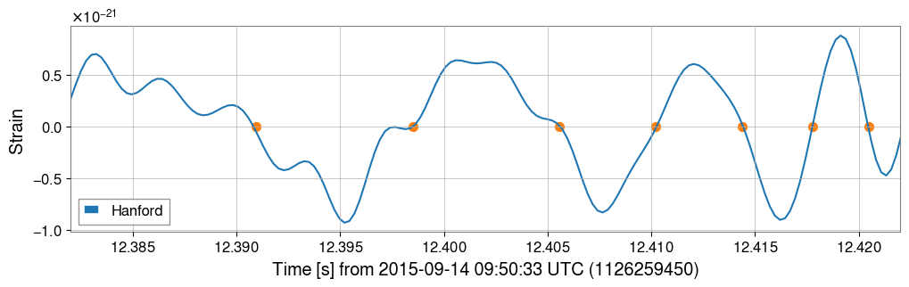

```python
fig, ax = plt.subplots(figsize=(12, 3))
ax.plot(hfilt.times.value, hfilt.value, label='Hanford')
ax.scatter(zero_cross_times, np.zeros(len(zero_cross_times)), color='C1', s=50)
ax.set_xlim(merger_time-0.04, merger_time)
ax.set_xlabel('Time [s] from 2015-09-14 09:50:33 UTC (1126259450)')
ax.set_ylabel('Strain')
ax.legend()
plt.show()
```

振幅が0となる時刻を7つ求めることができました。隣り合う2時刻の差から、その中心時刻での周波数を $f_{GW} = 1/(2\Delta t)$ で近似します。

```python
times = []
freqs = []
for i in range(1, len(zero_cross_times)):
    times.append((zero_cross_times[i-1]+zero_cross_times[i]) / 2)
    freqs.append(1 / (2*(zero_cross_times[i]-zero_cross_times[i-1])))
print(f"{freqs = }")
```

```
freqs = [66.06451612903226, 70.62068965517241, 107.78947368421052, 120.47058823529412, 146.28571428571428, 186.1818181818182]
```

6時刻での周波数を求めることができました。合体に近づくにつれ、周波数が増加していることも分かります。

式(1)から $f_{GW}^{-8/3}$ が時間に比例するため、横軸を時間、縦軸を周波数の $-8/3$ 乗としてプロットし、線形フィッティングします。$y=f_{GW}^{-8/3}$とすると

$$ y=at+b $$

でフィッティングしたときの傾き $a$ は

$$ a= -\frac{(8 \pi)^{8/3}}{5} \left( \frac{G \mathcal{M}}{c^3}\right)^{5/3} $$

に対応します。

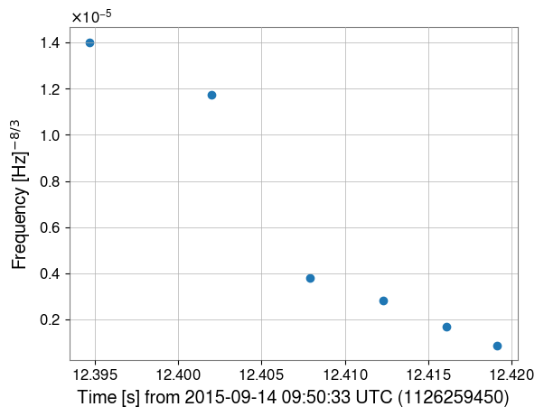

```python
freqs = np.array(freqs)
times = np.array(times)

fig, ax = plt.subplots()
ax.scatter(times, freqs**(-8/3))
ax.set_xlabel('Time [s] from 2015-09-14 09:50:33 UTC (1126259450)')
ax.set_ylabel(r'Frequency [Hz]${}^{-8/3}$')
plt.show()
```

線形フィッティングします。scipyの`curve_fit`を使います。

```python
# linear regression
def fit_func(t, a, b):
    return a * t + b

params, _ = curve_fit(fit_func, times, freqs**(-8/3))
```

```
傾き: -0.000588483531632989
```

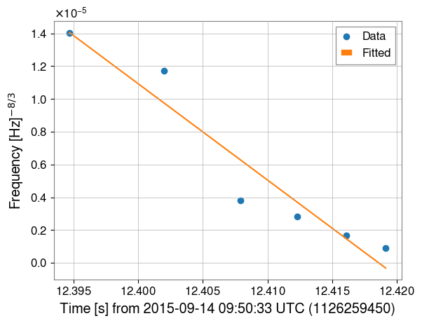

```python
sample_times = np.linspace(times[0], times[-1], 1000)
sample_freqs = params[0] * sample_times + params[1]

print(f'傾き: {params[0]}')

fig, ax = plt.subplots()
ax.scatter(times, freqs**(-8/3), label='Data')
ax.plot(sample_times, sample_freqs, c='C1', label='Fitted')
ax.set_xlabel('Time [s] from 2015-09-14 09:50:33 UTC (1126259450)')
ax.set_ylabel(r'Frequency [Hz]${}^{-8/3}$')
ax.legend()
plt.show()
```

チャープ質量は、この傾きを用いて

$$ \mathcal{M} = \frac{c^3}{G} \left( -\frac{5a}{(8 \pi)^{8/3}} \right)^{3/5} $$

と表せます。天文学では、質量の単位として太陽質量 $M_{\odot} = 1.9884 \times 10^{30}$ kg をよく用いられるため、これを使います。

```python
G = 6.6743e-11 # m3 kg−1 s−2
c = 29979e+4 # m s-1
Mc = (c**3/G) * (-5*params[0] / (8*np.pi)**(8/3))**(3/5)

Msun = 1.9884e30 # kg
print(f'Chirp mass = {Mc / Msun :.03f} Msun')
```

```
Chirp mass = 35.349 Msun
```

実際の解析では、質量は $m_1=36M_\odot, m_2=29M_\odot$ と解析されました [[Abbott et al.(2016)](https://doi.org/10.1103/PhysRevLett.116.061102)]。チャープ質量は

```python
(36*29)**(3/5) / (36+29)**(1/5)
```

```
28.09555579546043
```

$28M_\odot$ となります。この値よりは大きな値となりましたが、悪くない近似値です。

今回は連星の運動をニュートン近似しましたが、連星が近づくにつれて相対論的効果が大きくなり、ニュートン近似による波形からずれていきます。実際の解析では、ポスト・ニュートニアン近似による、より正確な波形を用いてマルコフ連鎖モンテカルロ法によるパラメータ推定が行われます。

### 課題: 有効距離$D_{\text{eff}}$の推定

連星からの重力波の振幅は次のように表されます [[Allen et al. (2012)](https://doi.org/10.48550/arXiv.gr-qc/0509116)]。

$$ h(t) = - \left( \frac{G \mathcal{M}}{c^2 D_{\text{eff}}} \right) \left( \frac{t_c-t}{5G \mathcal{M} / c^3} \right)^{-1/4} \cos[2\phi_0+2\phi(t-t_0; M, \mu)] \tag{A} $$

この cos の項が-1になる時刻 (極大値をとる時刻) を $t_{\text{peak}}$ とするとこの時刻での振幅は

$$ h(t_\text{peak}) = \left( \frac{G \mathcal{M}}{c^2 D_{\text{eff}}} \right) \left( \frac{t_c-t_\text{peak}}{5G \mathcal{M} / c^3} \right)^{-1/4} \tag{B} $$

です。つまり、$h(t_{\text{peak}})^{-4}$ が $(t_c-t_{\text{peak}})$ に比例します。その係数を求めることで、 $D_{\text{eff}}$ を推定することができます。

$$ h(t_\text{peak})^{-4} = at_\text{peak}+b \tag{C} $$

次の手順に従って、$D_{\text{eff}}$ を推定しましょう。

1. ここでは合体前の0.1sのHanfordでのデータを使うこととします。

   ```
   hcropped = hfilt.crop(merger_time-0.1, merger_time)
   ```

   を実行し、`hcropped`をプロットしましょう。
2. データのピーク点の時刻を求めましょう。 ここではscipyの `find_peaks()` メソッドを使います。

   ```
   from scipy.signal import find_peaks
   peak_indexes, _ = find_peaks(hcropped, height=xxx)
   ```

   ここで、`peaks` は `hcropped` の高さ xxx 以上のピークのインデックスのリストです。 上のプロットから適当なheightを選び、まず `peak_indexes` を求めましょう。次に、ピーク時刻とその振幅を求めましょう。
3. 2で求めた値と式(C)を使って線形フィッティングをしましょう。
4. 式(B)と式(C)から有効距離 $D_{\text{eff}}$ を $a$ を用いて表しましょう。次に、3で求めた傾きと先ほど推定したチャープ質量の値を使い、距離を Mpc の単位で表してください ($1\ \text{Mpc} = 3.086 \times 10^{22}\ \text{ m}$)。

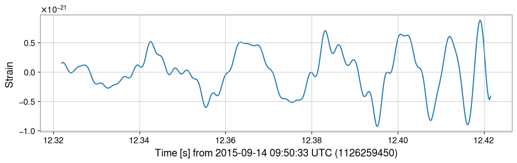

```python
hcropped = hfilt.crop(merger_time-0.1, merger_time)
fig, ax = plt.subplots(figsize=(12, 3))
ax.plot(hcropped.times.value, hcropped.value, label='Hanford')
ax.set_xlabel('Time [s] from 2015-09-14 09:50:33 UTC (1126259450)')
ax.set_ylabel('Strain')
plt.show()
```

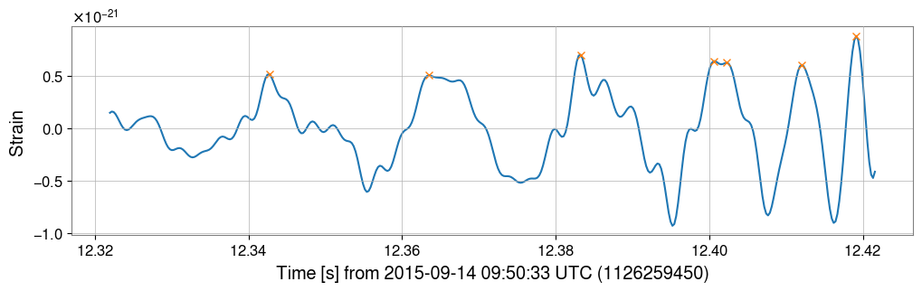

```python
from scipy.signal import find_peaks
peaks, _ = find_peaks(hcropped.value, height=5e-22)

fig, ax = plt.subplots(figsize=(12, 3))
ax.plot(hcropped.times.value, hcropped.value, label='Hanford')
ax.plot(hcropped.times.value[peaks], hcropped.value[peaks], "x")
ax.set_xlabel('Time [s] from 2015-09-14 09:50:33 UTC (1126259450)')
ax.set_ylabel('Strain')
plt.show()
```

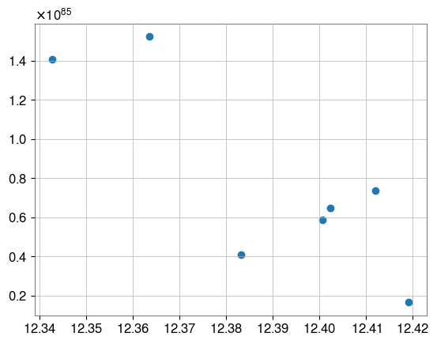

```python
peak_times = hcropped.times.value[peaks]
peak_amps = hcropped.value[peaks]

fig, ax = plt.subplots()
ax.scatter(peak_times, peak_amps**(-4))
plt.show()
```

値が大きすぎると、フィッティングが上手くいかないため、y軸の値は$10^{84}$で割ってから傾きを求めてスケールを戻すことにします。

```python
# linear regression
def fit_func(t, a, b):
    return a * t + b

params, _ = curve_fit(fit_func, peak_times, peak_amps**(-4)*1e-84)
params *= 1e84
print(params)
```

```
[-1.51528872e+86  1.88512659e+87]
```

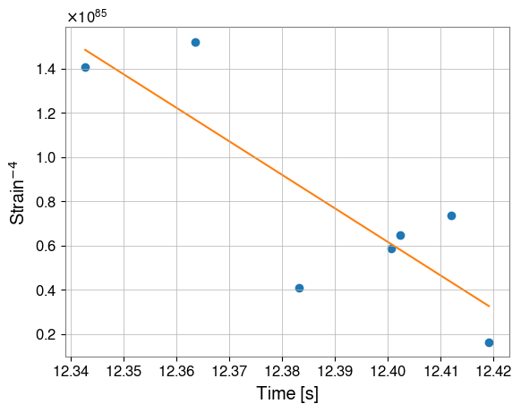

```python
sample_times = np.linspace(peak_times[0], peak_times[-1], 1000)
sample_freqs = params[0]*sample_times + params[1]

fig, ax = plt.subplots()
ax.scatter(peak_times, peak_amps**(-4))
ax.plot(sample_times, sample_freqs, c='C1')
ax.set_xlabel('Time [s]')
ax.set_ylabel(r'Strain${}^{-4}$')
plt.show()
```

$D_\text{eff}$ は傾き $a$ を使って次のように表せます。

$$ D_\text{eff} = \left(\frac{-5a G^5 \mathcal{M}^5}{c^{11}}\right)^{1/4} $$

```python
D_eff = (-5 * params[0]* G**5 * Mc** 5 / (c**11)) ** (1/4)
Mpc = 3.086e22 # m
print(f'{D_eff / Mpc :.2f} Mpc')
```

```
1019.38 Mpc
```

$D_\text{eff}$ は、検出器にとって最適な方向 (真上) から来た場合の連星の光学距離です。実際は真上から来ていないため、この値よりも連星は近いところにあります。HanfordとLivinstonのデータを使って解析された到来方向を考慮すると、本当の光学距離は $D_\text{eff}$ のおよそ2/3倍です。つまり、

```python
print(f'{D_eff / 1.5 / Mpc :.2f} Mpc')
```

```
679.59 Mpc
```

となります。また、チャープ質量も上の推定では実際より過大評価されているため、連星の距離はこの値よりもさらに小さくなるはずです。GW150914の論文[[Abbott et al.(2016)](https://doi.org/10.1103/PhysRevLett.116.061102)]では、410 Mpcと書かれています。